# Decision Trees

Manel Roumaissa Benabid

2022-05-02

```r
setwd("C:/Users/Owner/Desktop/LAU/Fall2022/CSC498H Data Mining")
```

# Importing libraries

```r
library(rpart)
library(rpart.plot)
library(tidyr)
library(tidyverse)
library(dplyr)
library(caTools)
library(Hmisc)
library(randomForest)
library(ggplot2)
library(pROC)
library(ROSE)
library(ipred) #bagging
library(Metrics)
library(caret)
set.seed(1)
```

Loading the dataset

We will use the life expectancy data but instead of predicting the life expectancy, we try to predict the Status variable which takes two levels: Developed , Developing

```r
df <- read.csv("life_expectancy.csv", header=TRUE)
```

```r
dim(df)
```

```
## [1] 2238   22
```

```r
colnames(df)
```

```
##  [1] "Country"                         "Year"
##  [3] "Status"                          "Life.expectancy"
##  [5] "Adult.Mortality"                 "infant.deaths"
##  [7] "Alcohol"                         "percentage.expenditure"
##  [9] "Hepatitis.B"                     "Measles"
## [11] "BMI"                             "under.five.deaths"
## [13] "Polio"                           "Total.expenditure"
## [15] "Diphtheria"                      "HIV.AIDS"
## [17] "GDP"                             "Population"
## [19] "thinness..1.19.years"            "thinness.5.9.years"
## [21] "Income.composition.of.resources" "Schooling"
```

We’re going to remove the country and the Year

```r
df <- df[ ,-c(1,2)]
head(df)
```

```
##       Status Life.expectancy Adult.Mortality infant.deaths Alcohol
## 1 Developing            65.0             263            62    0.01
## 2 Developing            59.9             271            64    0.01
## 3 Developing            59.9             268            66    0.01
## 4 Developing            59.5             272            69    0.01
## 5 Developing            59.2             275            71    0.01
## 6 Developing            58.8             279            74    0.01
##   percentage.expenditure Hepatitis.B Measles  BMI under.five.deaths    Polio
## 1              71.279624          65    1154 19.1                83 87.30377
## 2              73.523582          62     492 18.6                86 58.00000
## 3              73.219243          64     430 18.1                89 62.00000
## 4              78.184215          67    2787 17.6                93 67.00000
## 5               7.097109          68    3013 17.2                97 68.00000
## 6              79.679367          66    1989 16.7               102 66.00000
##   Total.expenditure Diphtheria HIV.AIDS       GDP Population
```

[output cut: 20 more lines]

```r
df$Status <- factor(df$Status)
```

## Train-test-split

```r
sample = sample.split(df$Status, SplitRatio = .80)
train = subset(df, sample==TRUE)
test = subset(df, sample==FALSE)
```

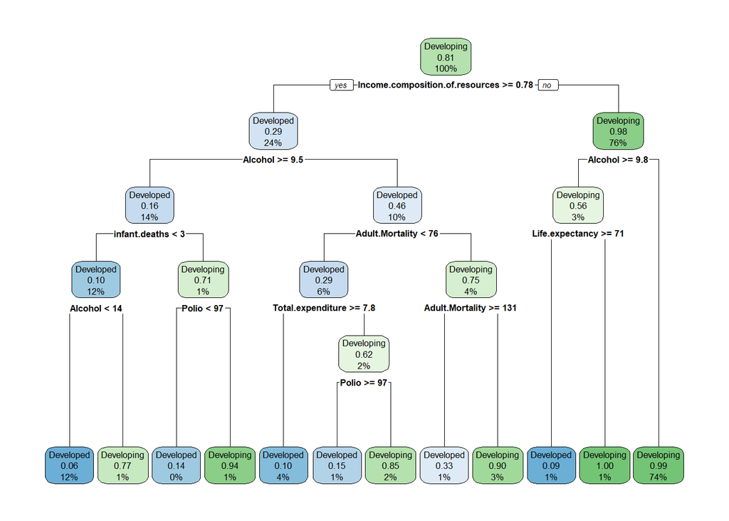

```r
life_tree <- rpart(formula = Status ~.,
                    data = train,
                   cp = 0.01,
                    method = "class")
rpart.plot(life_tree)
```

Going down each node the tree continues that way by splitting on different predictors.

Those were the information presented in the tree.

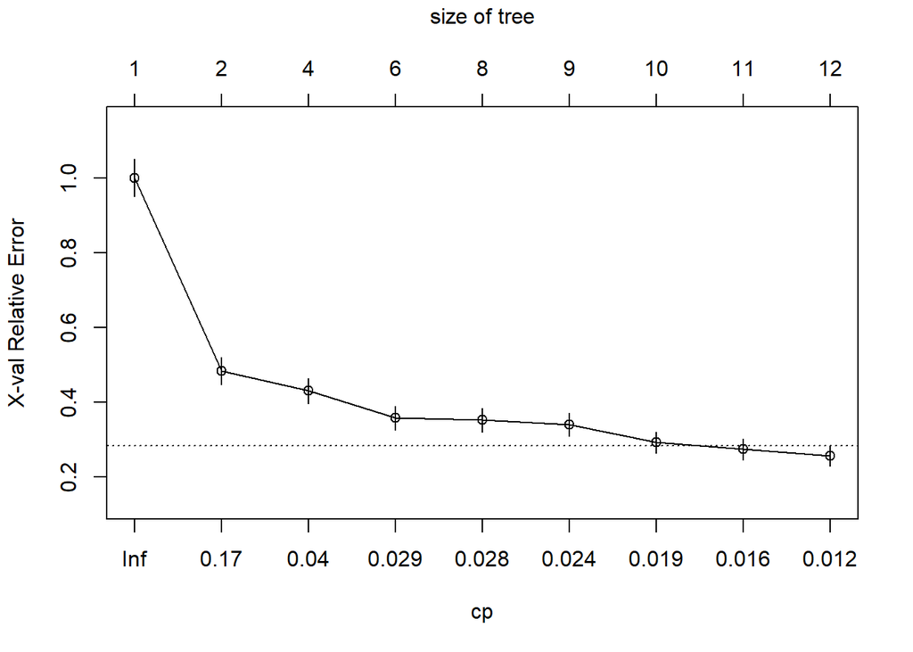

```r
#plotting the complexity parameter
plotcp(life_tree)
```

So the way rpart works is that it automatically applies a range of complexity α to perform pruning of the tree.

Rpart then performs 10-fold cross validation and calculates the error of a given α on the hold-out validation set, then it compares these errors.

In our case, we see diminishing returns after 12 terminal nodes as illustrated in our tree above

###### Let’s try a more complex tree

It is known that simple trees are preferred ver complex trees.

Let’s demonstrate that by setting cp = 0 i.e no penalty term and thus we get the full tree.

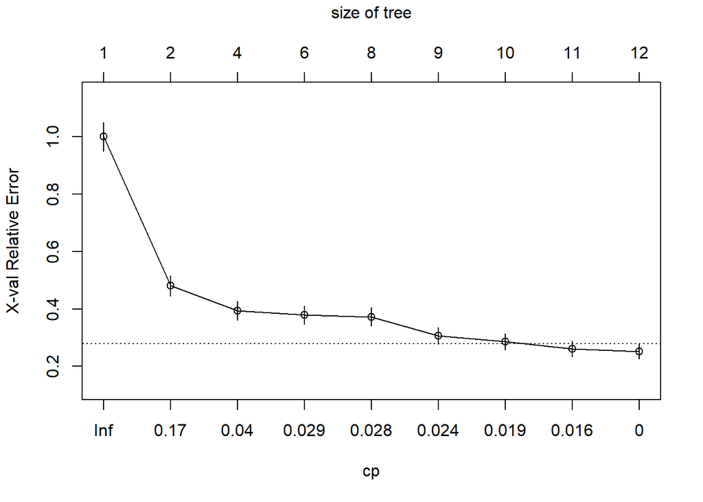

```r
full_life_tree <- rpart(formula = Status ~.,
                    data = train,
                   control = list(cp = 0, xval = 10),
                    method = "class")
plotcp(full_life_tree)
abline(v = 12, lty = "dashed")
```

```r
life_tree$cptable
```

```
##           CP nsplit rel error    xerror       xstd
## 1 0.53753754      0 1.0000000 1.0000000 0.04944346
## 2 0.05255255      1 0.4624625 0.4834835 0.03635086
## 3 0.03003003      3 0.3573574 0.4294294 0.03444725
## 4 0.02852853      5 0.2972973 0.3573574 0.03165189
## 5 0.02702703      7 0.2402402 0.3513514 0.03140354
## 6 0.02102102      8 0.2132132 0.3393393 0.03089891
## 7 0.01801802      9 0.1921922 0.2912913 0.02876408
## 8 0.01501502     10 0.1741742 0.2732733 0.02790957
## 9 0.01000000     11 0.1591592 0.2552553 0.02702134
```

hence, rpart is performing automated tuning with the optimal subtree of 11 splits and |T| = 12 and cross-validation error of 0.255 (PRESS stat).

Let’s try adding additional tuning to improve the performance of the model

## Tuning

For tuning, we will use the control argument to adjust the hyperparameters values: minsplit - minimum number of observations required to attempt a split before it’s forced to create a terminal node- and maxdepth - max number of internal nodes between the root node and the terminal node-.

#### Hyperparameter tuning

Instead of manually assessung multiple models for different values of minsplit and maxdepth, we will perfrom a grid search to automatically search across a range of differently tuned models to get the optimal hyperparameter

```r
# minsplit range: (5,0)
# maxdepth range:(8,15)

hyper_grid <- expand.grid(
  minsplit = seq(5, 20, 1),
  maxdepth = seq(8, 15, 1)
)
```

```r
head(hyper_grid)
```

```
##   minsplit maxdepth
## 1        5        8
## 2        6        8
## 3        7        8
## 4        8        8
## 5        9        8
## 6       10        8
```

```r
#number of combinations
nrow(hyper_grid)
```

```
## [1] 128
```

```r
#we will use a for loop to automate the search through each combination
#at each iteration we save the model

models <- list()

for (i in 1:nrow(hyper_grid)) {

  # get minsplit, maxdepth values at row i
  minsplit <- hyper_grid$minsplit[i]
  maxdepth <- hyper_grid$maxdepth[i]

  # train a model and store in the list
  models[[i]] <- rpart(formula = Status ~.,
                    data = train,
                   control = list(minsplit=minsplit,maxdepth=maxdepth),
    method = "class")

}
```

Next, we will extract the optimal cp and the minimum error associated with it for each model.

```r
# function to get optimal cp
get_cp <- function(x) {
  min    <- which.min(x$cptable[, "xerror"])
  cp <- x$cptable[min, "CP"]
}

# function to get minimum error
get_min_error <- function(x) {
  min    <- which.min(x$cptable[, "xerror"])
  xerror <- x$cptable[min, "xerror"]
}
```

```r
hyper_grid %>%
  mutate(
    cp    = purrr::map_dbl(models, get_cp),
    error = purrr::map_dbl(models, get_min_error)
    ) %>%
  arrange(error) %>%
  top_n(-5, wt = error)
```

```
##   minsplit maxdepth         cp     error
## 1       15       13 0.01000000 0.2102102
## 2       14       12 0.01501502 0.2132132
## 3        9       14 0.01000000 0.2132132
## 4        9       11 0.01000000 0.2162162
## 5       11       11 0.01000000 0.2162162
## 6       15       15 0.01000000 0.2162162
```

```r
optimal_life_tree <- rpart(formula = Status ~.,
                    data = train,
                   control = list(cp = 0.01, minsplit=13, maxdepth=13)
                   , method = "class")
```

```r
pred <- predict(optimal_life_tree, newdata = test, type="class")
```

```r
test$Status <- factor(test$Status)
```

```r
cm <- confusionMatrix(data=pred, reference = test$Status)
```

```r
cm
```

```
## Confusion Matrix and Statistics
##
##             Reference
## Prediction   Developed Developing
##   Developed         76          8
##   Developing         7        356
##
##                Accuracy : 0.9664
##                  95% CI : (0.9453, 0.9811)
##     No Information Rate : 0.8143
##     P-Value [Acc > NIR] : <2e-16
##
##                   Kappa : 0.8895
##
##  Mcnemar's Test P-Value : 1
##
##             Sensitivity : 0.9157
##             Specificity : 0.9780
##          Pos Pred Value : 0.9048
##          Neg Pred Value : 0.9807
##              Prevalence : 0.1857
##          Detection Rate : 0.1700
##    Detection Prevalence : 0.1879
##       Balanced Accuracy : 0.9468
##
##        'Positive' Class : Developed
##
```

We notice that we have an accuracy of 96.6% and precision of 90%. We conclude from this that the model we trained performed really well.

# Bagging

## Bagging with ipred

To fit the bagged model we use ipred::bagging instead of rpart we use coob = TRUE to use Out-Of-Bag sample to estimate the test error.

```r
set.seed(123)

# train bagged model
bagged_m1 <- bagging(
  formula = Status ~ .,
  data    = train,
  coob    = TRUE
)

bagged_m1
```

```
##
## Bagging classification trees with 25 bootstrap replications
##
## Call: bagging.data.frame(formula = Status ~ ., data = train, coob = TRUE)
##
## Out-of-bag estimate of misclassification error:  0.0279
```

The estimate misclassification error is 0.0279 years less than the test error we achieved with our single optimal tree.

It is important to note that the more trees the better (typically). as we add trees, we average over high variance single trees. Hence we see a dramatic reduction in variance (i.e our error). Eventually, the reduction in error will flatline => optimal number of trees to create a stable model.

Bagging performs 25 trees (from bootstrap samples) by default, we may need more tho.

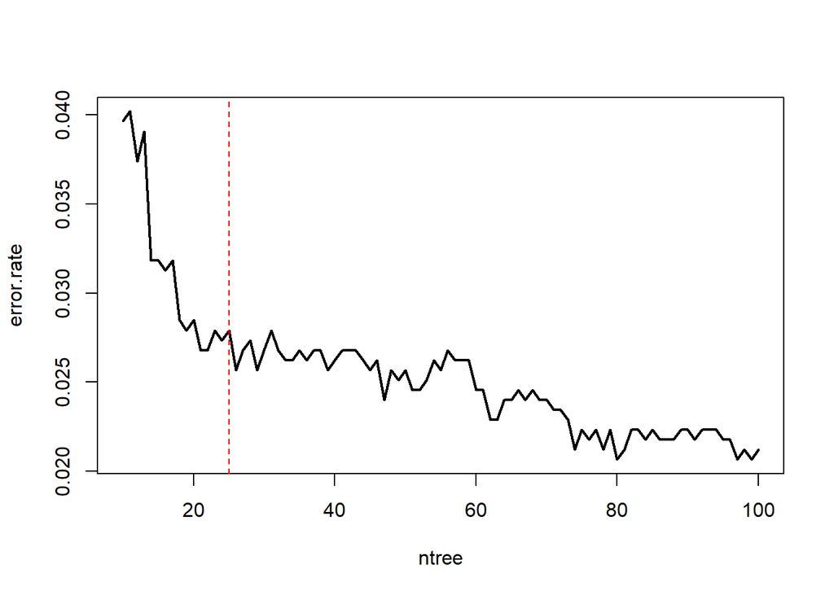

```r
# we will assess the error vs. #of trees

# assess 10-50 bagged trees
ntree <- 10:100

# create empty vector to store OOB RMSE values
error.rate <- vector(mode = "numeric", length = length(ntree))

for (i in seq_along(ntree)) {
  # reproducibility
  set.seed(123)

  # perform bagged model
  model <- bagging(
  formula = Status ~ .,
  data    = train,
  coob    = TRUE,
  nbagg   = ntree[i]
)
  # get OOB error
  error.rate[i] <- model$err
}

plot(ntree, error.rate, type = 'l', lwd = 2)
abline(v = 25, col = "red", lty = "dashed")
```

we notice that the misclassification rate differs by 0.01 which is not much for the computational power it requires, let’s try to test other methods.

### Bagging with caret

```r
# we perform 10-fold cross validation

# Specify 10-fold cross validation
ctrl <- trainControl(method = "cv",  number = 10)

# CV bagged model
bagged_cv <- train(
  Status ~ .,
  data = train,
  method = "treebag",
  trControl = ctrl,
  importance = TRUE
  )

# assess results
bagged_cv
```

```
## Bagged CART
##
## 1791 samples
##   19 predictor
##    2 classes: 'Developed', 'Developing'
##
## No pre-processing
## Resampling: Cross-Validated (10 fold)
## Summary of sample sizes: 1612, 1611, 1612, 1612, 1612, 1612, ...
## Resampling results:
##
##   Accuracy   Kappa
##   0.9771195  0.9241134
```

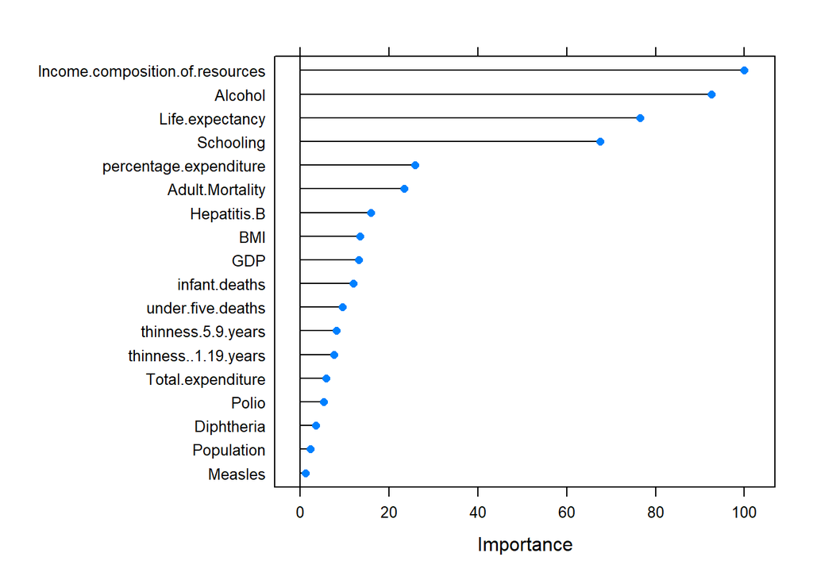

```r
# plot most important variables
plot(varImp(bagged_cv), 18)
```

We see that the cross-validated model accuracy is 0.977 years. We also assessed the importance of the variables from our model which is assessed by the total amount SSE is decreased by splits over a given predictor, averaged on all trees.

The most important variable in our model is income.composition.of.resources.

```r
pred <- predict(bagged_cv, test, method ="class")
cm <- confusionMatrix(data=pred, reference = test$Status)
```

```r
cm
```

```
## Confusion Matrix and Statistics
##
##             Reference
## Prediction   Developed Developing
##   Developed         80          5
##   Developing         3        359
##
##                Accuracy : 0.9821
##                  95% CI : (0.965, 0.9922)
##     No Information Rate : 0.8143
##     P-Value [Acc > NIR] : <2e-16
##
##                   Kappa : 0.9414
##
##  Mcnemar's Test P-Value : 0.7237
##
##             Sensitivity : 0.9639
##             Specificity : 0.9863
##          Pos Pred Value : 0.9412
##          Neg Pred Value : 0.9917
##              Prevalence : 0.1857
##          Detection Rate : 0.1790
##    Detection Prevalence : 0.1902
##       Balanced Accuracy : 0.9751
##
##        'Positive' Class : Developed
##
```

Comparing this result to the previous model we see that the cross-validated accuracy has been improved to approx 98.2%.

We are satisfied with our results.

# Random Forest

```r
library(ranger)
# for reproduciblity
set.seed(123)

# default RF model
rf1 <- randomForest(
  formula = Status ~ .,
  data    = train
)

rf1
```

```
##
## Call:
##  randomForest(formula = Status ~ ., data = train)
##                Type of random forest: classification
##                      Number of trees: 500
## No. of variables tried at each split: 4
##
##         OOB estimate of  error rate: 1.68%
## Confusion matrix:
##            Developed Developing class.error
## Developed        319         14  0.04204204
## Developing        16       1442  0.01097394
```

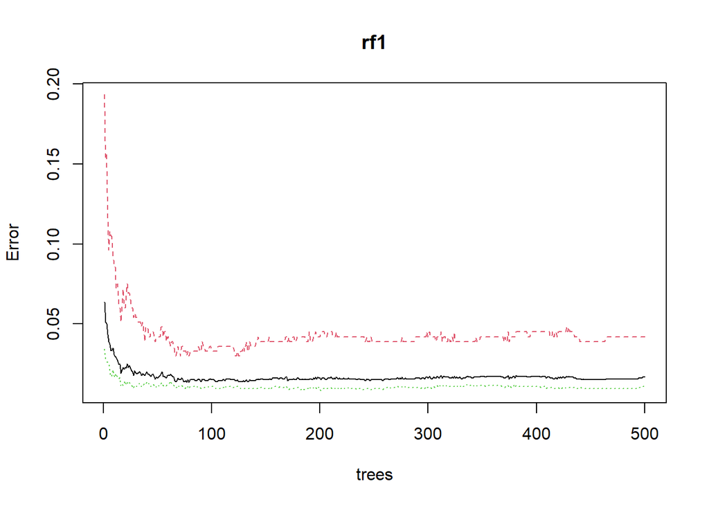

```r
plot(rf1)
```

```r
#which.min(rf1$err.rate[:,1])
range <- 1:dim(rf1$err.rate)[1]
mini <- 1
for(i in range){
  if(mini > rf1$err.rate[i,1]){
    mini <- rf1$err.rate[i,1]
  }
}
mini
```

```
##        OOB
## 0.01340034
```

```r
#we will split the training set further to create training and validation set

# create training and validation data
set.seed(123)
valid_split <- sample.split(train$Status, SplitRatio = .80)


# training data
train_v2 <- subset(train, valid_split==TRUE)

# validation data
valid <- subset(train, valid_split==FALSE)
x_test <- valid[, -which(names(valid)== "Status")]
y_test <- valid$Status

rf_oob_comp <- randomForest(
  formula = Status ~ .,
  data    = train_v2,
  xtest   = x_test,
  ytest   = y_test
)
```

```r
rf_oob_comp
```

```
##
## Call:
##  randomForest(formula = Status ~ ., data = train_v2, xtest = x_test,      ytest = y_test)
##                Type of random forest: classification
##                      Number of trees: 500
## No. of variables tried at each split: 4
##
##         OOB estimate of  error rate: 2.16%
## Confusion matrix:
##            Developed Developing class.error
## Developed        251         15  0.05639098
## Developing        16       1150  0.01372213
##                 Test set error rate: 1.95%
## Confusion matrix:
##            Developed Developing class.error
## Developed         64          3  0.04477612
## Developing         4        288  0.01369863
```

```r
# extract OOB & validation errors
oob <- rf_oob_comp$err.rate
validation <- rf_oob_comp$test$err.rate
```

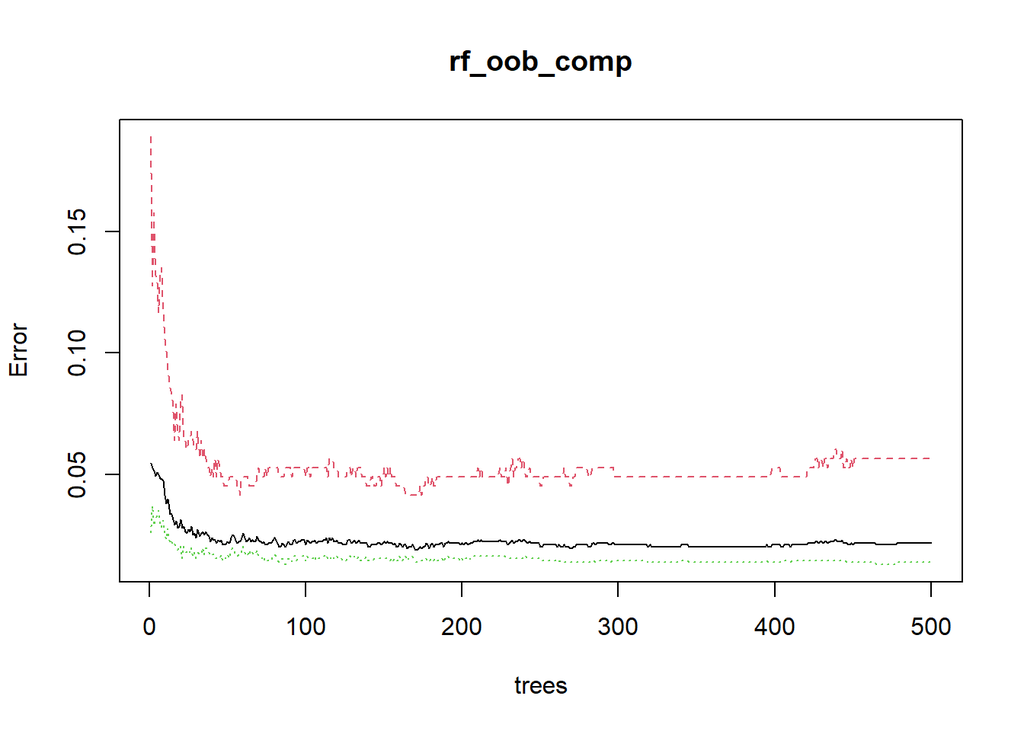

```r
plot(rf_oob_comp)
```

# Conclusion

We performed classification decision trees, hyperparameter tuning, bagging, and random forest to predict the status of the observation as Developing of Developed.

We obtained the best results using random forest and decision trees with bagging and hyperparameter tuning.